# BS2280 – Econometrics I

# Homework 5: Multiple Regression Model I

## Question 1

When we interpret the coefficients of a multiple regression model, we always add “holding everything else constant”. Using an example, explain what it means.

Holding all other variables constant: Other X variables do not change when X variable of interest is changing. If they all change at the same time, it would be difficult to assess the effect of a change in the X variable of interest on Y. A change in one X variable could increase Y, but a change in another X variable could decrease Y and so on. This would not be informative.

Example:

$$\begin{equation*}
\widehat{officers}_{i}=\hat{\beta}_{1}+\hat{\beta}_{2}
crimes_{i}+\hat{\beta}_{3} population_{i}+\hat{\beta}_{4} pcinc_{i}
\end{equation*}$$

A one unit increase in crimes would increase the number of police officers by $\hat{\beta}_{2}$ keeping everything else constant, i.e. population and per capita income.

## Question 2

Data on 935 individuals was collected to identify what factors can explain the variation in wage data. Firstly, a simple regression is run regressing wages (monthly earnings in USD) on years of education. Secondly, a multiple regression is run regressing wages on years of education and years of work experience.

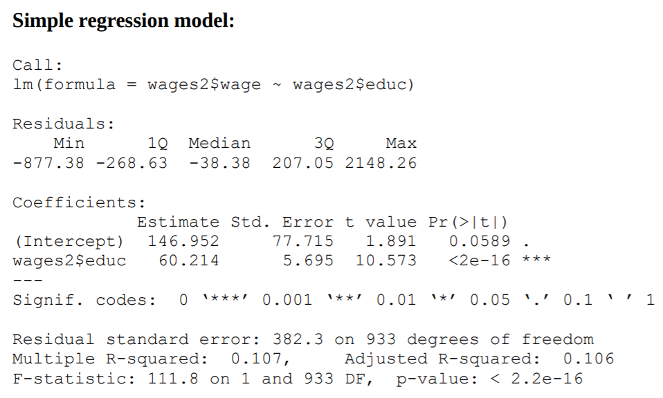

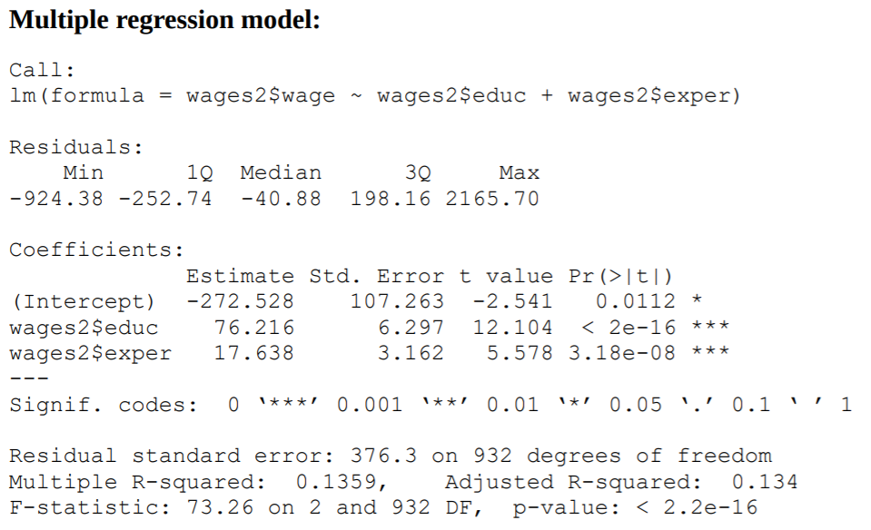

1. Interpret the intercepts and coefficients of both regressions and make reference to their statistical significance.
- Regression 1 - Simple regression model:

Intercept: estimate coefficient = 146.952

A person without education would have on average a monthly income of 146.952USD. The $p-value=0.0589 >5\%$ shows that we cannot reject the null hypothesis at the 5% significance level, therefore the intercept is statistically insignificant.

wages2$educ: estimate coefficient = 60.214

One more year of education will increase monthly earning on average by 60.214USD. The $p-value <2e-16 < 1\%$. This value is highly statistically significant. We can reject the null hypothesis at the 1% significance level.

- Regression 2 - Multiple regression model:

Intercept: estimate coefficient = -272.528.

A person without education and without work experience would have on average a negative monthly income of 272.528USD. The $p-value=0.0112 <5\%$ shows that we can reject the null hypothesis at the 5% significance level, therefore the intercept is statistically significant. Note that the intercept is an out-of-sample estimate, therefore be careful with its interpretation.

wages2$educ: estimate coefficient = 76.216.

One more year of education will increase monthly earning on average by 76.216USD, ceteris paribus. The $p-value <2e-16 < 1\%$. This value is highly statistically significant. We can reject the null hypothesis at the 1% significance level.

wages2$exper: estimate coefficient = 17.638.

One more year of work experience will increase monthly earning on average by 17.638USD, ceteris paribus. The $p-value=3.18e-08< 1\%$. This value is highly statistically significant. We can reject the null hypothesis at the 1% significance level.

2. Explain why the omission of the work experience variable in the simple regression model led to an underestimation of the impact of education on wages.

Work experience and education both have positive impact on wages. However, education and work experience are negatively correlated, i.e. individuals with more education have on average less work experience. By not controlling for work experience (not adding work experience to our model), the coefficient of education would also capture the work experience effect, therefore the impact of education would be underestimated.

3. Using the multiple regression model, predict the wage of someone who has 12 years of education and 1 year of work experience.

Writing out the estimated regression model will be helpful.

Wage of someone who has 12 years of education and 1 year of work experience is:
$$\begin{equation*}
\widehat{wage}=-272.528+76.216\times12+17.638\times1=659.702
\end{equation*}$$

## Question 3

The output below is the result of fitting an educational attainment function, regressing $S$ on $ASVABC$, a measure of cognitive ability, $SM$, and $SF$, years of schooling (highest grade completed) of the respondent’s mother and father, respectively.

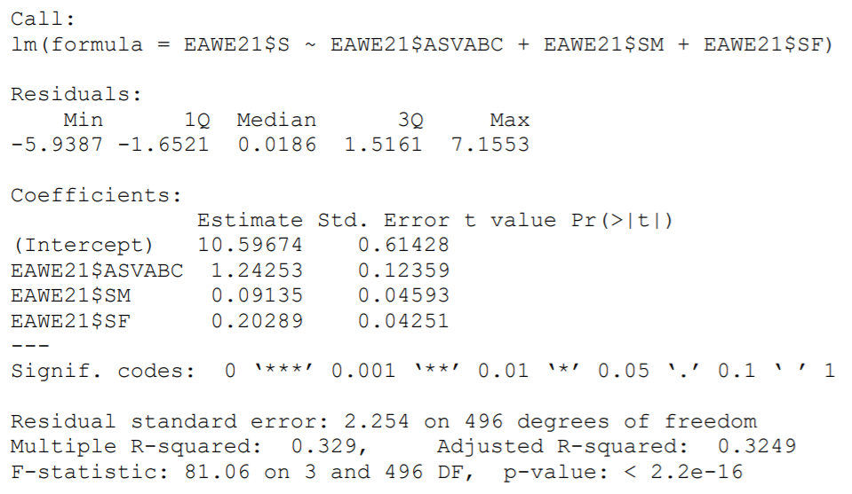

1. Give an interpretation of the regression coefficients.

Intercept: estimate coefficient = 10.59674.

$ASVABC$: estimate coefficient = 1.24253.

A one unit higher cognitive ability score will increase years of education on average by 1.24253 years, ceteris paribus.

$SM$: estimate coefficient = 0.09135

A year more of education of the mother will lead on average to a 0.09135 years increase of years of education, ceteris paribus.

$SF$: estimate coefficient = 0.20289

A year more of education of the father will lead on average to a 0.20289 years increase of education, ceteris paribus.

2. Undertake hypothesis tests to show whether the coefficients are statistically significant. The critical $t-value = 1.965$ (5% significance level).

To test whether any of the coefficients provided above are statistically significant, we need to follow these steps:

Step 1. State the null and alternative hypotheses

Step 2. Select the significance level

Step 3. Select and calculate the test statistics

Step 4. Set the decision rule

Step 5. Make statistical decisions

- Hypothesis test for intercept

Step 1. $H_0:\beta_{1}=0; H_1:\beta_{1}\neq 0$

Step 2. Significance level: 5%

Step 3. Calculate t-statistic: $\hat{\beta}_{1}=10.59674$, s.e.$(\hat{\beta}_{1})=0.61428$

$t=\frac{\hat{\beta}_{1}-\beta_{1}^0}{s.e.(\hat{\beta}_{1})}=\frac{10.59674-0}{0.61428} \approx 17.25$

Step 4. Compare t-statistic with critical t -value: $17.25 > 1.965$

Step 5. Conclusion: We can reject the null hypothesis at the 5% significance level. The intercept is statistically significant.

- Hypothesis test for $ASVABC$

Step 1. $H_0:\beta_{2}=0; H_1:\beta_{2}\neq 0$

Step 2. Significance level: 5%

Step 3. Calculate t-statistic: $\hat{\beta}_{2}=1.24253$, s.e.$(\hat{\beta}_{2})=0.12359$

$$\begin{equation*}
t=\frac{\hat{\beta}_{2}-\beta_{2}^0}{s.e.(\hat{\beta}_{2})}=\frac{1.24253-0}{0.12359}
\approx 10.05
\end{equation*}$$

- Hypothesis test for $SM$

Step 2. Significance level: 5%

Step 3. Calculate t-statistic:

$t=\frac{\hat{\beta}_{3}-\beta_{3}^0}{s.e.(\hat{\beta}_{3})}=\frac{0.09135-0}{0.04593} \approx 1.98$

Step 4. Compare t-statistic with critical t -value: $1.98 > 1.965$

Step 5. Conclusion: We can reject the null hypothesis at the 5% significance level. The intercept is statistically significant.

- Hypothesis test for $SF$

Step 1. $H_0:\beta_{4}=0$; $H_1:\beta_{4}\neq 0$

Step 3. Calculate t-statistic:

$\hat{\beta}_{4}=0.20289$, s.e.$(\hat{\beta}_{4})=0.04251$

$$\begin{equation*}
t=\frac{\hat{\beta}_{4}-\beta_{4}^0}{s.e.(\hat{\beta}_{4})}=\frac{0.20289-0}{0.04251}
\approx 4.77
\end{equation*}$$

Step 4. Compare t-statistic with critical t -value: 4.77 > 1.965

Step 5. Conclusion: We can reject the null hypothesis at the 5% significance level. The intercept is statistically significant.

3. Is the $R^2$ is statistically significant? The critical F value at the 5% significance level is 2.62. Interpret your result.

Step 1. Write hypothesis test for $R^2$: $H_0:R^2=0; H_1:R^2 \neq 0$

Step 2. Significance level: 5%

Step 3. Calculate F-statistic:

You can use $R^2$ to calculate the F-statistic (or find it in the output table).

$R^2=0.329$

$k=4$

$n=500$

$$\begin{equation*}
F(3,496)=\frac{R^2/(k-1)}{(1-R^2)/(n-k)}=\frac{0.329/(4-1)}{(1-0.329)/496}
\approx 81.06
\end{equation*}$$

Step 4. Compare F test statistic with the critical F-value: 81.06 > 2.62

Step 5. The F statistic is greater than the critical F value, therefore we can reject the null hypothesis. The estimated model is statistically significant.

4. Calculate the 95% confidence interval for each coefficient.

The formula for calculating the confidence interval for the intercept is
$$\begin{equation*}
\hat{\beta}_{1}-s.e.(\hat{\beta}_{1}) \times t_{crit} \leq \beta_{1}
\leq \hat{\beta}_{1}+s.e.(\hat{\beta}_{1}) \times t_{crit}
\end{equation*}$$

The regression output shows that the point estimate $\beta_{1}$ is 10.59674 and its standard error is 0.61428:

$$\begin{equation*}
10.59674-0.61428 \times 1.965 \leq \beta_{1} \leq 10.59674+0.61428
\times 1.965
\end{equation*}$$

The 95% confidence interval for intercept is
$$\begin{equation*}
9.3896 \leq \beta_{1} \leq 11.8038
\end{equation*}$$

Following the same logic, you can calculate the 95% confidence interval for $ASVABC$, $SM$ and $SF$ (Fill in the table below with four decimal places):

[output not shown]

|  | 2.5% | 97.5% |
| --- | --- | --- |
| 95% confidence interval for intercept | 9.3896 | 11.8038 |
| 95% confidence interval for $ASVABC$ | 0.9997 | 1.4853 |
| 95% confidence interval for $SM$ | 0.0011 | 0.1815 |
| 95% confidence interval for $SF$ | 0.1193 | 0.2864 |

## Question 4

Explain the differences between $R^2$ and adjusted $R^2$ and calculate adjusted $R^2$ using the information from question 3. The formula of adjusted $R^2$ is

$$\begin{equation*}
\bar{R^2}=R^2-\frac{k-1}{n-k}(1-R^2)
\end{equation*}$$

$R^2$ is a measure of goodness of fit, which measures the percentage of the total variation in the dependent variable that is explained by the independent variables in the regression model.

However, the more $X$ variables are on the right-hand side of a regression model the higher $R^2$ usually tends to be. Adding random variables could improve the model fit by chance, therefore a direct comparison of models with a different number of variables is misleading.

$k=4$

$n=500$

$$\begin{equation*}
\bar{R^2}=R^2-\frac{k-1}{n-k}(1-R^2)=0.329-\frac{4-1}{496}(1-0.329)=0.3249
\end{equation*}$$